# 野場排球球員實力評分模型（R）

StatSoft 期末專題：R 實質任務

2026-11-26

# 1 這一份在做什麼

研究問題：**用比賽結果估出的球員實力來分隊，是否比隨機分隊或依自報程度分隊更勢均力敵？** 要回答它，第一步是有一個能從「每局名單＋比分」估出每位球員實力、並附上不確定區間的模型。 這份文件就是那個模型，以及三層驗證：

1. **真實公開比分**（德國排球甲級聯賽 6,330 局）：模型能不能預測下半季？
2. **自己的模擬資料**（真實實力已知）：估不估得回來？95% 區間是否真的涵蓋 95%？需要幾晚資料？
3. **Python 模擬器的野場資料**（產生機制跟模型不同）：模型設定不完全正確時還好不好用？

> 所有野場資料都是模擬的，沒有真實人物。真實野場紀錄不在本專題範圍內。

# 2 資料格式

模型只需要每局一列：

| 欄位 | 說明 | 例 |
| --- | --- | --- |
| `date`, `session` | 日期、時段（晚餐場／消夜場） | 2026-09-14, 晚餐場 |
| `game_id` | 局編號 | 17 |
| `team_a`, `team_b` | 兩隊名單，以 `;` 分隔球員代號 | `P03;P11;P27;P30;P38` |
| `score_a`, `score_b` | 該局比分 | 25, 21 |

選用：球員表 `player, level`（自報程度 1–5）。Python 模擬器輸出的長格式（`game_players.csv`）由 `R/read_volley_sim.R` 自動轉換。

# 3 模型

## 3.1 逐球的 Bradley–Terry 模型

把一局看成很多個「球」（rally）。設 A 隊每一球得分的機率為 $p$，

$$\operatorname{logit}(p) = \underbrace{\bar\theta_A -
\bar\theta_B}_{\text{個人實力平均之差}}
+ \underbrace{\bar\gamma_A - \bar\gamma_B}_{\text{隊內搭檔默契平均之差}}
+ \underbrace{\delta\,(n_A - n_B)}_{\text{人數差}}$$

- $\theta_i$：球員 $i$ 的實力（logit 尺度；差 0.1 約等於每球得分機率差 2.5 個百分點）。
- $\gamma_{jk}$：$j,k$ 兩人同隊時的額外默契（扣掉兩人各自實力後的**交互作用**）。
- $\delta$：多一個人的優勢（野場常有 4 打 5）。

**為什麼可以直接把比分當二項資料？** 若每球獨立、得分機率都是 $p$，一局「先到 25 分且領先 2 分」的停止規則只看比分、不看 $p$，所以任一比分序列的機率是「常數 $\times\, p^{a}(1-p)^{b}$」。對 $p$ 而言，似然函數跟二項分佈完全一樣（似然原則），不需要逐球紀錄。這個「每球獨立」假設在第 4.3 節用真實比分檢查。

## 3.2 先驗與收縮（階層模型）

$$\theta_i \sim N\!\big(\beta\,(\text{自報程度}_i - 3),\
\sigma^2\big),\qquad
\gamma_{jk} \sim N(0,\ \tau^2),\qquad \beta \sim N(0, 10^2),\ \delta
\sim N(0,1)$$

- **自報程度當先驗平均**：打得少的人，估計值會被拉向「同程度的人的平均」；打得多的人，主要由比賽結果決定。$\beta$ 由資料估計，所以自報準不準也是資料說了算。
- **搭檔效果收縮到 0**：兩人同隊的局數通常很少，若不收縮，「默契」幾乎都是雜訊。$\tau$ 由資料估計；資料不足以支持默契時，$\hat\tau \to 0$，模型自動退回只有個人實力。

## 3.3 估計方法

1. 給定 $(\sigma, \tau)$，用 Newton 法（IRLS）求後驗眾數（MAP）。
2. 用 Laplace 近似算邊際概似 $\log p(\text{資料}\mid\sigma,\tau)$，最大化它得到 $\hat\sigma, \hat\tau$（經驗貝氏）。
3. 95% 區間 = MAP $\pm 1.96\times$ 後驗標準差（Hessian 反矩陣的對角線）。實力以「相對全體平均」呈現。

全部只用 base R 與 `Matrix`（稀疏矩陣），程式碼在 `R/rating_model.R`，可以逐行讀懂，不依賴黑盒套件。

# 4 驗證一：真實公開比分（德國排球甲級聯賽）

## 4.1 資料

R 套件 **volleystat**（Bozhinov, CC0 授權）收錄 2013/14–2018/19 德甲男女聯賽每一局的比分，原始資料來自聯賽官網。共 6,330 局、12 個「聯賽 × 球季」。 這裡把**每支隊伍當成一位「球員」**（名單只有自己），套用同一個模型。每個球季用**上半季**估計，**預測下半季每一局誰贏**（3,105 局）。

## 4.2 預測結果

| 方法 | 測試局數 | Log loss（越低越好） | Brier | 命中率 |
| --- | --- | --- | --- | --- |
| 模型（經驗貝氏收縮） | 3105 | 0.585 | 0.200 | 0.685 |
| 模型（幾乎不收縮，≈ 最大概似） | 3105 | 0.580 | 0.198 | 0.686 |
| 擲硬幣基準 | 3105 | 0.693 | 0.250 | 0.500 |

模型猜中下半季 **69%** 的局，log loss 從擲硬幣的 0.693 降到 0.585。在職業聯賽裡每隊上半季就打了 30 局以上，所以收縮與否差異很小；收縮的價值在資料少的時候才出現（見第 5 節）。

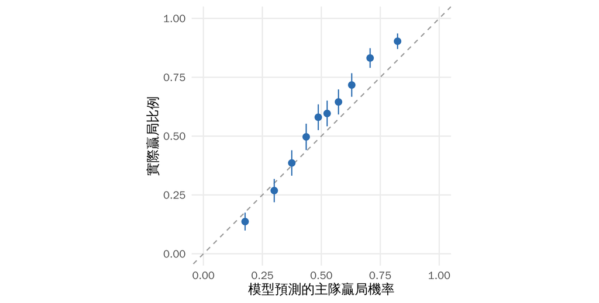

校準圖：把預測勝率分成 10 組，比較預測與實際勝率。點越貼近對角線，代表機率越可信。

## 4.3 「每球獨立」假設檢查

若每球真的獨立，可以從每局的預測得分機率算出「打到 24:24 進入 deuce」的期望次數： 期望 **323** 局，實際 **374** 局（比例 1.16）。 實際的膠著局多了約 16%，表示比賽有一點「落後時更拚、領先時放鬆」的動態，每球並不完全獨立。這會讓模型對**比分差**的不確定性稍微低估，但不影響「誰比較強」的排序；報告中列為限制。

## 4.4 從真實資料借的參數

職業聯賽各隊實力的離散程度 $\hat\sigma_{\text{隊}}$ 在 0.07–0.17 之間（logit／每球），每局（非決勝局）平均分差 5.8 分。 野場是隨機湊隊、程度落差更大，所以模擬時設個人實力 $\sigma = 0.5$：5 人隊伍平均後隊伍實力的標準差約 0.22，兩隊差距約 0.32，比職業聯賽大一些，模擬出來每局平均分差約 6.2 分。這是**假設**，第 5.4 節用 $\sigma = 0.3$ 做敏感度分析。

# 5 驗證二：模擬研究（真實實力已知）

## 5.1 設計

- 球員池 40 人，真實實力 $\theta_i \sim N(0, 0.5^2)$；搭檔默契 $\gamma_{jk} \sim N(0, 0.3^2)$（雙重中心化成純交互作用）。
- 自報程度 = 真實實力加雜訊後切成 1–5 級，與真實實力的相關約 0.7。
- 每晚 4–6 隊、每隊 4–6 人、隨機分隊，打 12 局；逐球模擬，每局打到 20 分（30% 是 15 分短局，皆須贏 2 分），對應政大野場晚餐場、消夜場的規則。
- 分別用 **4、8、16、32 晚** 的資料估計，另外再模擬 4 晚當「未來」測試資料。每個情境重複 200 次。

比較的方法：

| 代號 | 方法 |
| --- | --- |
| B1 | 只看自報程度 |
| B2 | 原始得分率（該員所在隊伍的得分 ÷ 總分） |
| M1 | 個人 Bradley–Terry，無自報先驗、無搭檔 |
| M2 | M1 + 自報程度先驗 |
| M3 | M2 + 搭檔默契（完整模型） |

## 5.2 需要幾晚的資料？

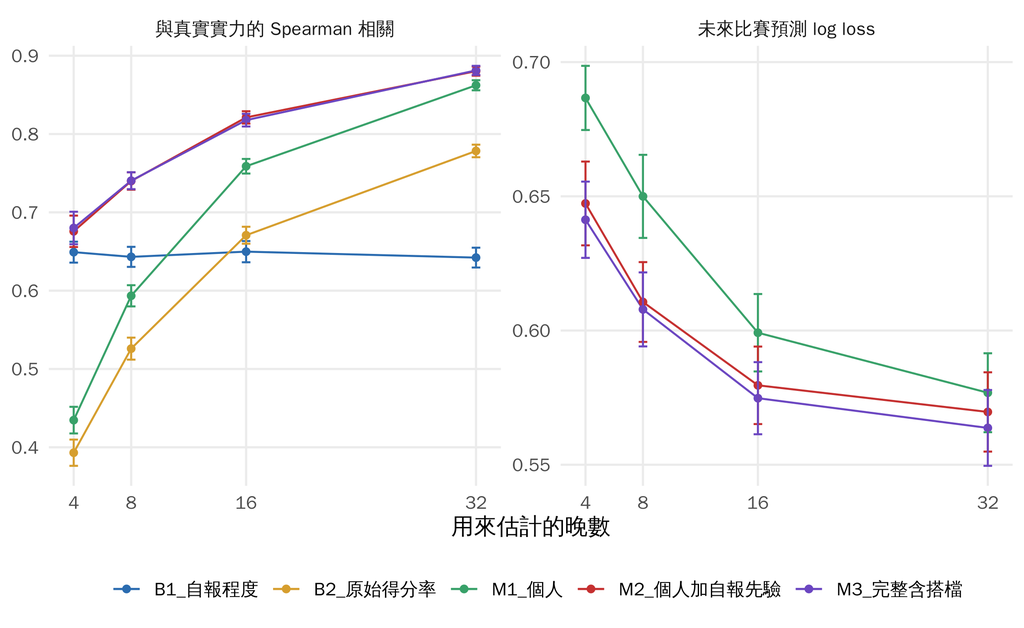

左：估計實力與真實實力的 Spearman 相關（排序準不準）。右：預測未來 4 晚每局勝負的 log loss（越低越好）。誤差棒為重複間的 95% 信賴區間。

| 晚數 | 約局數 | 方法 | Spearman | RMSE | 95%區間涵蓋率 | 區間平均寬度 | 預測 log loss |
| --- | --- | --- | --- | --- | --- | --- | --- |
| 4 | 48 | B1_自報程度 | 0.65 |  |  |  |  |
| 4 | 48 | B2_原始得分率 | 0.39 |  |  |  |  |
| 4 | 48 | M1_個人 | 0.43 | 0.45 | 91.8% | 1.77 | 0.687 |
| 4 | 48 | M2_個人加自報先驗 | 0.68 | 0.37 | 90.2% | 1.49 | 0.647 |
| 4 | 48 | M3_完整含搭檔 | 0.68 | 0.38 | 73.5% | 1.13 | 0.641 |
| 8 | 96 | B1_自報程度 | 0.64 |  |  |  |  |
| 8 | 96 | B2_原始得分率 | 0.53 |  |  |  |  |
| 8 | 96 | M1_個人 | 0.59 | 0.40 | 93.2% | 1.53 | 0.650 |
| 8 | 96 | M2_個人加自報先驗 | 0.74 | 0.33 | 93.2% | 1.28 | 0.611 |
| 8 | 96 | M3_完整含搭檔 | 0.74 | 0.33 | 79.7% | 1.03 | 0.608 |
| 16 | 192 | B1_自報程度 | 0.65 |  |  |  |  |
| 16 | 192 | B2_原始得分率 | 0.67 |  |  |  |  |
| 16 | 192 | M1_個人 | 0.76 | 0.32 | 92.3% | 1.14 | 0.599 |
| 16 | 192 | M2_個人加自報先驗 | 0.82 | 0.28 | 92.9% | 1.01 | 0.580 |
| 16 | 192 | M3_完整含搭檔 | 0.82 | 0.28 | 91.1% | 0.99 | 0.575 |
| 32 | 384 | B1_自報程度 | 0.64 |  |  |  |  |
| 32 | 384 | B2_原始得分率 | 0.78 |  |  |  |  |
| 32 | 384 | M1_個人 | 0.86 | 0.23 | 90.8% | 0.77 | 0.577 |
| 32 | 384 | M2_個人加自報先驗 | 0.88 | 0.21 | 90.9% | 0.72 | 0.570 |
| 32 | 384 | M3_完整含搭檔 | 0.88 | 0.21 | 93.8% | 0.82 | 0.564 |

重點：

- **自報先驗在資料少時最有用。** 只有 4 晚時，M2 的排序相關 0.68，高於只看比賽的 M1（0.43）和只看自報的 B1（0.65）。兩種資訊合起來勝過任何一種。
- **比原始得分率好。** 得分率會被隊友拖累或帶飛；模型同時考慮所有隊友與對手，16 晚時相關 0.82 vs 得分率 0.67。
- **區間大致可信，但略窄。** M2 的 95% 區間實際涵蓋率約 90%–93%，略低於名目的 95%。原因是經驗貝氏把估出來的 $\hat\sigma$ 當成已知，忽略了它本身的不確定性；報告時可以說「區間略為樂觀」，或改用 97.5% 區間當保守版本。
- 約 **16 晚（約 190 局）** 後，排序相關達 0.82；32 晚約 0.88。15／20 分的短局每局資訊比 25 分局少，所以需要的晚數比想像多。

## 5.3 搭檔默契估得出來嗎？

| 晚數 | 估計值與真實默契的相關 | 95% 區間涵蓋率 | 估計的 τ（真值 0.3） |
| --- | --- | --- | --- |
| 4 | 0.10 | 50.7% | 0.24 |
| 8 | 0.11 | 64.4% | 0.28 |
| 16 | 0.13 | 78.4% | 0.27 |
| 32 | 0.18 | 88.8% | 0.29 |

**幾乎估不出來。**即使 32 晚，估計的默契與真實默契的相關仍很低。原因是 40 人有 780 種兩兩組合，每對同隊的局數很少；而且默契藏在 4–6 人平均裡，訊號被稀釋。 收縮估計讓大部分默契被拉回 0，所以加入搭檔項（M3）的排序相關與預測跟 M2 幾乎一樣；但**資料少時 M3 會讓個人實力的區間變得太窄**（4 晚時涵蓋率只有 74%），因為一部分個人差異被誤歸給默契。**所以分隊時建議用 M2 的實力估計**，M3 只用來探索默契。 **對報告的意義**：「跟誰很合」可以做成探索性指標（例如同隊局數 ≥ 5 才顯示），但要附上區間並註明證據薄弱，不能當成分隊依據。

## 5.4 敏感度分析（16 晚）

| 情境（Spearman 相關） | B1_自報程度 | M1_個人 | M2_個人加自報先驗 | M3_完整含搭檔 | M2 涵蓋率 |
| --- | --- | --- | --- | --- | --- |
| 基準（σ=0.5, τ=0.3, r=0.7, 隨機分隊） | 0.65 | 0.76 | 0.82 | 0.82 | 92.9% |
| 依自報程度分隊 | 0.64 | 0.57 | 0.77 | 0.77 | 92.3% |
| 實力差異小 σ=0.3 | 0.65 | 0.60 | 0.72 | 0.73 | 92.1% |
| 無搭檔效果 τ=0 | 0.64 | 0.79 | 0.84 | 0.84 | 93.7% |
| 自報相關低 r=0.3 | 0.27 | 0.75 | 0.76 | 0.75 | 92.3% |

# 6 驗證三：Python 模擬器的野場資料

另一條工作線的 Python 模擬器（`volley-sim`，種子 20261126）用**完全不同的機制**產生資料：逐球模擬發球、攻擊、攔網，默契只存在於 10% 的組合，人數不足會扣分，每局打 15 或 20 分。共 229 局、79 位有出場的球員。模型不知道這些細節，是對「模型設定不完全正確」的考驗。

| 方法 | Spearman | Pearson | σ 估計 | τ 估計 | δ 估計（多一人） |
| --- | --- | --- | --- | --- | --- |
| B1_自報程度 | 0.77 | 0.77 |  |  |  |
| M1_個人 | 0.69 | 0.74 | 0.54 |  | -0.06 |
| M2_個人加自報先驗 | 0.86 | 0.88 | 0.42 |  | -0.01 |
| M3_完整含搭檔 | 0.86 | 0.88 | 0.42 | 0.005 | -0.01 |

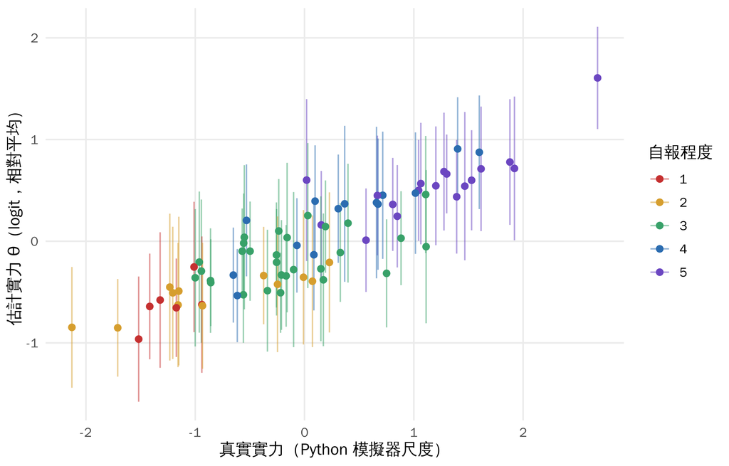

M2 估計實力（含 95% 區間）與模擬器真實實力。顏色為自報程度。

估計結果已輸出成 `output/ratings_volley_sim.csv`（欄位：player, theta, se, lower, upper, level, sets），Python 分隊原型可直接讀入，用 `theta` 做「依模型實力分隊」。

# 7 結論與限制

**結論**

1. 以「每局名單＋比分」配合逐球 Bradley–Terry 模型，可以估出球員實力與 95% 區間（模擬中實際涵蓋率約 91–93%，略為樂觀）。
2. 自報程度當先驗，在資料少時、以及依自報程度分隊時，大幅改善估計；自報不準時，模型會自動降低它的權重。
3. 15／20 分短局的野場，大約 16 晚（約 190 局）後排序相關達 0.8 以上，結合自報後足以作為分隊依據。分隊建議使用 M2（不含默契）的估計。
4. 搭檔默契在野場的資料量下幾乎無法辨識，應只當探索性指標。
5. 在真實職業比分上，模型對下半季的單局勝負命中率約 69%。

**限制**

- 每球獨立假設略不成立（真實比賽 deuce 比預期多約 16%）。
- 野場參數（實力離散、自報相關）是假設，只能以敏感度分析處理；公開資料都是職業／青年正式比賽。
- 實力假設在學期內不變；若要追蹤進步，可擴充為隨時間變動的狀態空間模型。
- 只用比分，沒有用到攻擊成功率等技術統計；那部分可另外做描述統計。

# 8 重現方式

```
Rscript analysis/01_bundesliga.R          # 約 5 秒
R_REPS=200 Rscript analysis/02_simulation_study.R  # 4 核心約 25 分鐘
Rscript analysis/03_volley_sim.R          # 約 10 秒（需要 volley-sim 資料夾）
Rscript -e 'rmarkdown::render("report.Rmd")'
```

所有隨機過程都有固定種子。套件：R version 4.3.3 (2024-02-29)，Matrix 1.6.5，ggplot2 3.4.4，rmarkdown 2.25。

**資料來源與授權**

| 資料 | 來源 | 授權 | 用途 |
| --- | --- | --- | --- |
| 德甲排球 2013/14–2018/19 每局比分 | R 套件 volleystat（github.com/bozhinvi/volleystat，commit c385865），原始資料：volleyball-bundesliga.de | CC0 | 樣本外驗證、借參數 |
| DataVolley 範例比賽 | R 套件 datavolley（github.com/openvolley/datavolley） | MIT | Python 模擬器的技術統計基準（見 volley-sim/README） |
| 野場資料 | 本專題模擬產生 | — | 模型驗證 |